# Problem Statement

Pneumonia is an infection in one or both lungs. Bacteria, viruses, and fungi cause it. The infection causes inflammation in the air sacs in your lungs, which are called alveoli.

Now to detection Pneumonia we need to detect Inflammation of the lungs. In this project, you’re challenged to build an algorithm to detect a visual signal for pneumonia in medical images. Specifically, your algorithm needs to automatically locate lung opacities on chest radiographs.

Business Domain Value Automating Pneumonia screening in chest radiographs, providing affected area details through bounding box. Assist physicians to make better clinical decisions or even replace human judgement in certain functional areas of healthcare (eg, radiology).

Project objective In this capstone project, the goal is to build a pneumonia detection system, to locate the position of inflammation in an image.

# Import Libraries and read files

```python
!pip install pydicom
import warnings
warnings.filterwarnings('ignore')
```

```python
import tensorflow
print(tensorflow.__version__)
import pandas as pd
import pylab
import matplotlib.pyplot as plt
from os.path import dirname, join
from pprint import pprint

import pydicom as dcm
from pydicom.data import get_testdata_file
from pydicom.filereader import read_dicomdir


import pandas as pd
import numpy as np
import matplotlib
import matplotlib.pyplot as plt
from tqdm import tqdm_notebook
#from tqdm.notebook import tqdm
from matplotlib.patches import Rectangle
import seaborn as sns
%matplotlib inline
import os
```

```
1.14.0
```

```python
 print("Current Working Directory " , os.getcwd())
```

```
Current Working Directory  /run/media/root/GRMCPRXVOL_/Capstone
```

```python
train_images_path = "rsna-pneumonia-detection-challenge//stage_2_train_images//%s.dcm"
```

```python
detailed_class_file = 'rsna-pneumonia-detection-challenge/stage_2_detailed_class_info.csv'
train_labels_file = 'rsna-pneumonia-detection-challenge/stage_2_train_labels.csv'
detailed_class_info = 'rsna-pneumonia-detection-challenge/stage_2_detailed_class_info.csv'
```

```python
detailed_class_file
```

```
'rsna-pneumonia-detection-challenge/stage_2_detailed_class_info.csv'
```

```python
data_class = pd.read_csv(detailed_class_file)
```

```python
data_train_Labels = pd.read_csv(train_labels_file)
```

```python
data_class_info = pd.read_csv(detailed_class_info)
```

# Exploratory Data Analysis

```python
data_class.head()
```

|  | patientId | class |
| --- | --- | --- |
| 0 | 0004cfab-14fd-4e49-80ba-63a80b6bddd6 | No Lung Opacity / Not Normal |
| 1 | 00313ee0-9eaa-42f4-b0ab-c148ed3241cd | No Lung Opacity / Not Normal |
| 2 | 00322d4d-1c29-4943-afc9-b6754be640eb | No Lung Opacity / Not Normal |
| 3 | 003d8fa0-6bf1-40ed-b54c-ac657f8495c5 | Normal |
| 4 | 00436515-870c-4b36-a041-de91049b9ab4 | Lung Opacity |

```python
data_class.shape
```

```
(30227, 2)
```

```python
data_train_Labels.head()
```

|  | patientId | x | y | width | height | Target |
| --- | --- | --- | --- | --- | --- | --- |
| 0 | 0004cfab-14fd-4e49-80ba-63a80b6bddd6 | NaN | NaN | NaN | NaN | 0 |
| 1 | 00313ee0-9eaa-42f4-b0ab-c148ed3241cd | NaN | NaN | NaN | NaN | 0 |
| 2 | 00322d4d-1c29-4943-afc9-b6754be640eb | NaN | NaN | NaN | NaN | 0 |
| 3 | 003d8fa0-6bf1-40ed-b54c-ac657f8495c5 | NaN | NaN | NaN | NaN | 0 |
| 4 | 00436515-870c-4b36-a041-de91049b9ab4 | 264.0 | 152.0 | 213.0 | 379.0 | 1 |

```python
data_train_Labels.shape
```

```
(30227, 6)
```

```python
train_df = pd.concat([data_train_Labels,data_class["class"]],axis=1,sort=False )
```

```python
train_df.shape
```

```
(30227, 7)
```

```python
train_df.head()
```

|  | patientId | x | y | width | height | Target | class |
| --- | --- | --- | --- | --- | --- | --- | --- |
| 0 | 0004cfab-14fd-4e49-80ba-63a80b6bddd6 | NaN | NaN | NaN | NaN | 0 | No Lung Opacity / Not Normal |
| 1 | 00313ee0-9eaa-42f4-b0ab-c148ed3241cd | NaN | NaN | NaN | NaN | 0 | No Lung Opacity / Not Normal |
| 2 | 00322d4d-1c29-4943-afc9-b6754be640eb | NaN | NaN | NaN | NaN | 0 | No Lung Opacity / Not Normal |
| 3 | 003d8fa0-6bf1-40ed-b54c-ac657f8495c5 | NaN | NaN | NaN | NaN | 0 | Normal |
| 4 | 00436515-870c-4b36-a041-de91049b9ab4 | 264.0 | 152.0 | 213.0 | 379.0 | 1 | Lung Opacity |

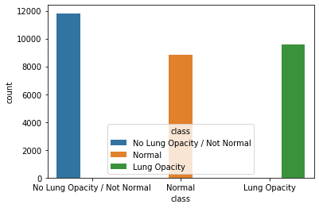

```python
import seaborn as sns
graph = sns.countplot(x="class", hue="class", data=train_df)
```

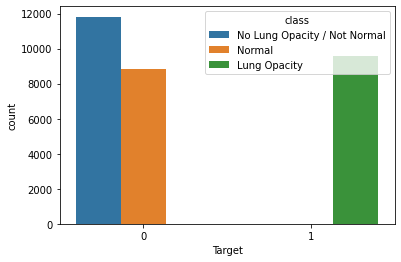

```python
graph2 = sns.countplot(x="Target", hue="class", data=train_df)
```

```python
train_df['class'].value_counts()
```

```
No Lung Opacity / Not Normal    11821
Lung Opacity                     9555
Normal                           8851
Name: class, dtype: int64
```

```python
train_df['Target'].value_counts()
```

```
0    20672
1     9555
Name: Target, dtype: int64
```

```python
train_df.info()
```

```
<class 'pandas.core.frame.DataFrame'>
RangeIndex: 30227 entries, 0 to 30226
Data columns (total 7 columns):
 #   Column     Non-Null Count  Dtype
---  ------     --------------  -----
 0   patientId  30227 non-null  object
 1   x          9555 non-null   float64
 2   y          9555 non-null   float64
 3   width      9555 non-null   float64
 4   height     9555 non-null   float64
 5   Target     30227 non-null  int64
 6   class      30227 non-null  object
dtypes: float64(4), int64(1), object(2)
memory usage: 1.6+ MB
```

```python
train_df.describe(include="all")
```

|  | patientId | x | y | width | height | Target | class |
| --- | --- | --- | --- | --- | --- | --- | --- |
| count | 30227 | 9555.000000 | 9555.000000 | 9555.000000 | 9555.000000 | 30227.000000 | 30227 |
| unique | 26684 | NaN | NaN | NaN | NaN | NaN | 3 |
| top | ee820aa5-4804-4984-97b3-f0a71d69702f | NaN | NaN | NaN | NaN | NaN | No Lung Opacity / Not Normal |
| freq | 4 | NaN | NaN | NaN | NaN | NaN | 11821 |
| mean | NaN | 394.047724 | 366.839560 | 218.471376 | 329.269702 | 0.316108 | NaN |
| std | NaN | 204.574172 | 148.940488 | 59.289475 | 157.750755 | 0.464963 | NaN |
| min | NaN | 2.000000 | 2.000000 | 40.000000 | 45.000000 | 0.000000 | NaN |
| 25% | NaN | 207.000000 | 249.000000 | 177.000000 | 203.000000 | 0.000000 | NaN |
| 50% | NaN | 324.000000 | 365.000000 | 217.000000 | 298.000000 | 0.000000 | NaN |
| 75% | NaN | 594.000000 | 478.500000 | 259.000000 | 438.000000 | 1.000000 | NaN |
| max | NaN | 835.000000 | 881.000000 | 528.000000 | 942.000000 | 1.000000 | NaN |

```python
# count of Unique patients
train_df['patientId'].value_counts().shape[0]
```

```
26684
```

```python
# count of duplicate records
train_df[train_df.duplicated(subset='patientId')].count().max()
```

```
3543
```